# am5088_hw6

Anika Mitchell

2024-12-01

Load libraries

```r
library(tidyverse)
library(dplyr)
library(modelr)
library(purrr)
library(broom)
```

Load data

```r
weather_df =
  rnoaa::meteo_pull_monitors(
    c("USW00094728"),
    var = c("PRCP", "TMIN", "TMAX"),
    date_min = "2017-01-01",
    date_max = "2017-12-31") %>%
  mutate(
    name = recode(id, USW00094728 = "CentralPark_NY"),
    tmin = tmin / 10,
    tmax = tmax / 10) %>%
  select(name, id, everything())
```

```
## using cached file: /Users/anika/Library/Caches/org.R-project.R/R/rnoaa/noaa_ghcnd/USW00094728.dly
```

```
## date created (size, mb): 2024-12-01 11:46:47.503913 (8.667)
```

```
## file min/max dates: 1869-01-01 / 2024-11-30
```

Use 5000 bootstrap samples and, for each bootstrap sample, produce estimates of these two quantities

```r
set.seed(123)
boot_results = map(1:5000, ~{
boot_sample = weather_df %>% sample_frac(size = 1, replace = TRUE)
lm(tmax ~ tmin, data = boot_sample)
model = lm(tmax ~ tmin, data = boot_sample)
tibble(
  rsq = broom::glance(model)$r.squared,
  log_beta0_beta1 = log(broom::tidy(model)$estimate[1] * broom::tidy(model)$estimate[2])
  )
})
boot_results_df = tibble(
rsq = map_dbl(boot_results, "rsq"),
log_beta0_beta1 = map_dbl(boot_results, "log_beta0_beta1")
)
```

Plot distribution for R^2

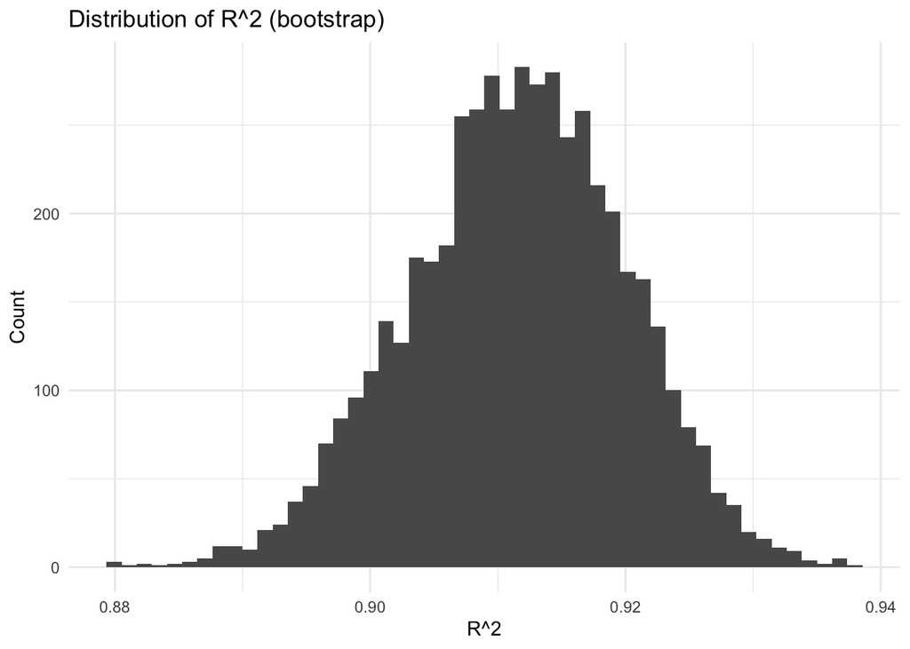

```r
ggplot(boot_results_df, aes(x = rsq)) +
geom_histogram(bins = 50) +
theme_minimal() +
labs(title = "Distribution of R^2 (bootstrap)", x = "R^2", y = "Count")
```

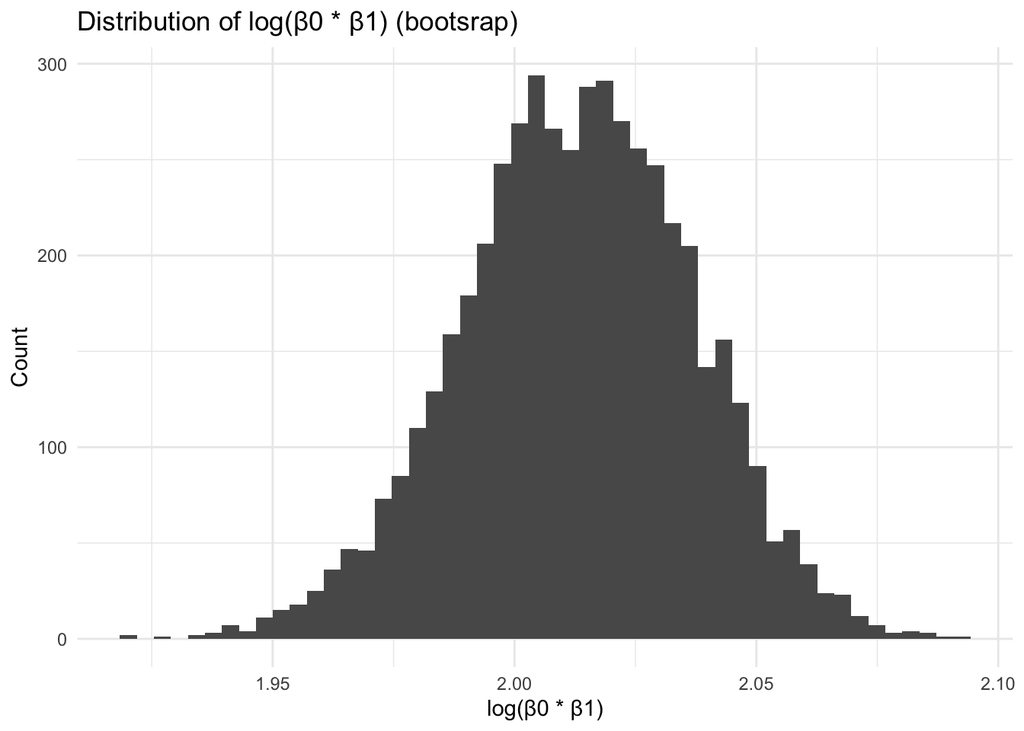

```r
ggplot(boot_results_df, aes(x = log_beta0_beta1)) +
geom_histogram(bins = 50) +
theme_minimal() +
labs(title = "Distribution of log(β0 * β1) (bootsrap)", x = "log(β0 * β1)", y = "Count")
```

**Both distributions look pretty normal.**

##Problem 2 Read in data

```r
wposthomicide_data = read_csv("https://raw.githubusercontent.com/washingtonpost/data-homicides/master/homicide-data.csv")
```

Create a city_state variable (e.g. “Baltimore, MD”), and a binary variable indicating whether the homicide is solved. Omit cities Dallas, TX; Phoenix, AZ; and Kansas City, MO – these don’t report victim race. Also omit Tulsa, AL – this is a data entry mistake. For this problem, limit your analysis those for whom victim_race is white or black. Be sure that victim_age is numeric.

Data wrangling/cleaning

```r
cleaned_homicide_data <- wposthomicide_data |>
  mutate(
  city_state = paste(city, state, sep = ", "),
  resolved = if_else(disposition == "Closed by arrest", 1, 0),
  victim_race = factor(victim_race),
  victim_age = as.numeric(victim_age)) |>
  filter(
    !city_state %in% c("Dallas, TX", "Phoenix, AZ", "Kansas City, MO", "Tulsa, AL"),
    victim_race %in% c("White", "Black")
  )
cleaned_homicide_data |>
group_by(city_state) |>
filter(n() >= 10)
```

```
## # A tibble: 39,693 × 14
## # Groups:   city_state [47]
##    uid        reported_date victim_last  victim_first victim_race victim_age
##    <chr>              <dbl> <chr>        <chr>        <fct>            <dbl>
##  1 Alb-000003      20100601 SATTERFIELD  VIVIANA      White               15
##  2 Alb-000005      20100102 MULA         VIVIAN       White               72
##  3 Alb-000006      20100126 BOOK         GERALDINE    White               91
##  4 Alb-000009      20100130 MARTIN-LEYVA GUSTAVO      White               56
##  5 Alb-000012      20100218 LUJAN        KEVIN        White               NA
##  6 Alb-000016      20100308 GRAY         STEFANIA     White               43
##  7 Alb-000018      20100323 DAVID        LARRY        White               52
##  8 Alb-000019      20100402 BRITO        ELIZABETH    White               22
##  9 Alb-000021      20100423 KING         TEVION       Black               15
## 10 Alb-000022      20100423 BOYKIN       CEDRIC       Black               25
## # ℹ 39,683 more rows
## # ℹ 8 more variables: victim_sex <chr>, city <chr>, state <chr>, lat <dbl>,
## #   lon <dbl>, disposition <chr>, city_state <chr>, resolved <dbl>
```

For the city of Baltimore, MD, use the glm function to fit a logistic regression with resolved vs unresolved as the outcome and victim age, sex and race as predictors.

Log Regression: Balitomre + output with estimate and confidence intervals

```r
baltimore_data <- cleaned_homicide_data |>
  filter(city_state == "Baltimore, MD")

baltimore_model <- glm(
  resolved ~ victim_age + victim_sex + victim_race,
  data = baltimore_data,
  family = binomial()
)

baltimore_data_results <- broom::tidy(baltimore_model, conf.int = TRUE, exponentiate = TRUE) |>
filter(term == "victim_sexMale")

baltimore_data_results
```

```
## # A tibble: 1 × 7
##   term           estimate std.error statistic  p.value conf.low conf.high
##   <chr>             <dbl>     <dbl>     <dbl>    <dbl>    <dbl>     <dbl>
## 1 victim_sexMale    0.426     0.138     -6.18 6.26e-10    0.324     0.558
```

Log Regression: All Cities

```r
all_city_results <- cleaned_homicide_data |>
group_by(city_state) |>
nest() |>
mutate(
  model = map(data, ~glm(resolved ~ victim_age + victim_sex + victim_race, data = .x, family = binomial())),
  tidy_model = map(model, ~broom::tidy(.x, conf.int = TRUE, exponentiate = TRUE))
  ) |>
  unnest(tidy_model) |>
  filter(term == "victim_sexMale")
```

Create a plot that shows the estimated ORs and CIs for each city. Organize cities according to estimated OR, and comment on the plot.

Plot for ALl Cities:

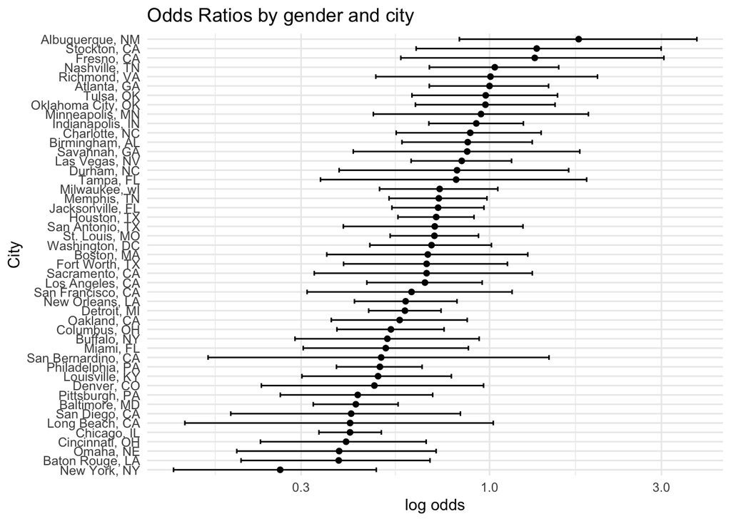

```r
city_results_sorted <- all_city_results |>
arrange(estimate)
ggplot(city_results_sorted, aes(x = reorder(city_state, estimate), y = estimate)) +
geom_point() +
geom_errorbar(aes(ymin = conf.low, ymax = conf.high), width = 0.5) +
coord_flip() +
theme_minimal() +
labs(
    title = "Odds Ratios by gender and city",
    x = "City",
    y = "log odds"
  ) +
scale_y_log10()
```

##Problem 3: Load and clean the data for regression analysis (i.e. convert numeric to factor where appropriate, check for missing data, etc.).

load data

```r
birthweight_data <- read_csv("/Users/anika/Desktop/building_blocks/HW6/am5088_hw6/birthweight.csv")
```

data wrangling + get rid of missing data

```r
cleaned_birthweight_data <- birthweight_data |>
mutate(
    malform = factor(malform, levels = c(0, 1), labels = c("Absent", "Present")),
    babysex = factor(babysex, levels = c(1, 2), labels = c("Male", "Female")),
    frace = factor(frace),
    mrace = factor(mrace)
  ) |>
  drop_na()
```

Propose a regression model for birthweight. This model may be based on a hypothesized structure for the factors that underly birthweight, on a data-driven model-building process, or a combination of the two. Describe your modeling process and show a plot of model residuals against fitted values – use add_predictions and add_residuals in making this plot.

```r
child_bw_model <- lm(bwt ~ blength + bhead + fincome + gaweeks + smoken, data = cleaned_birthweight_data)

summary(child_bw_model)
```

```
##
## Call:
## lm(formula = bwt ~ blength + bhead + fincome + gaweeks + smoken,
##     data = cleaned_birthweight_data)
##
## Residuals:
##      Min       1Q   Median       3Q      Max
## -1124.92  -190.90   -10.16   180.20  2604.06
##
## Coefficients:
##               Estimate Std. Error t value Pr(>|t|)
## (Intercept) -6134.6881    96.0588 -63.864  < 2e-16 ***
## blength        81.2980     2.0716  39.245  < 2e-16 ***
## bhead         136.6187     3.5160  38.857  < 2e-16 ***
## fincome         1.2552     0.1680   7.470 9.64e-14 ***
## gaweeks        14.2282     1.5043   9.458  < 2e-16 ***
## smoken         -2.2173     0.5867  -3.780 0.000159 ***
## ---
## Signif. codes:  0 '***' 0.001 '**' 0.01 '*' 0.05 '.' 0.1 ' ' 1
##
## Residual standard error: 284 on 4336 degrees of freedom
## Multiple R-squared:  0.6928, Adjusted R-squared:  0.6924
## F-statistic:  1955 on 5 and 4336 DF,  p-value: < 2.2e-16
```

*the factors that my model includes are general anthropometric measurements like length, and head circumference. I also included family income, gestational age (weeks), and mother’s smoking data. I expect these predictors to have a linear relationship with the outcome (ch bw). I chose not to select too many factors to try and prevent overfitting but I did want to have a mix of baby data + mom/SES data.*

plot residuals against fitted values:

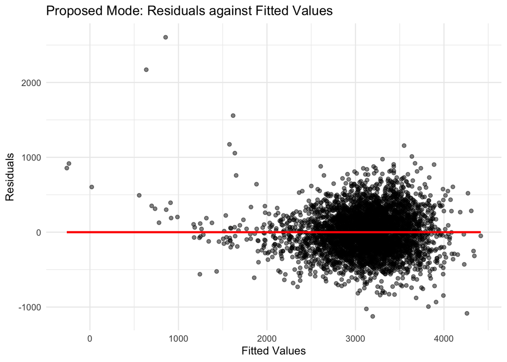

```r
birthweight_with_residuals <- cleaned_birthweight_data |>
  add_predictions(child_bw_model) |>
  add_residuals(child_bw_model)

ggplot(birthweight_with_residuals, aes(x = pred, y = resid)) +
  geom_point(alpha = 0.5) +
  geom_smooth(method = "lm", se = FALSE, color = "red") +
  theme_minimal() +
  labs(
    title = "Proposed Mode: Residuals against Fitted Values",
    x = "Fitted Values",
    y = "Residuals"
  )
```

Hi TA, this is a quick comment that for some reason (probably because I used an absolute path sorry), my code runs but then sometimes it then tells me that the file doesn’t exist and then I go to the folder and it is deleted? Not by me, so then I redownload it in and run it and it works. I’m not sure what the reason is but it’s probably the reason not to rely on absolute paths, but also I was running into errors reading in the data and on a time crunch. Just writing this here in case that causes an error too. I have screenshots of it working. Thanks! -Anika